# **Nowoczesne raportowanie zarządcze z wykorzystaniem AI i narzędzi data science**

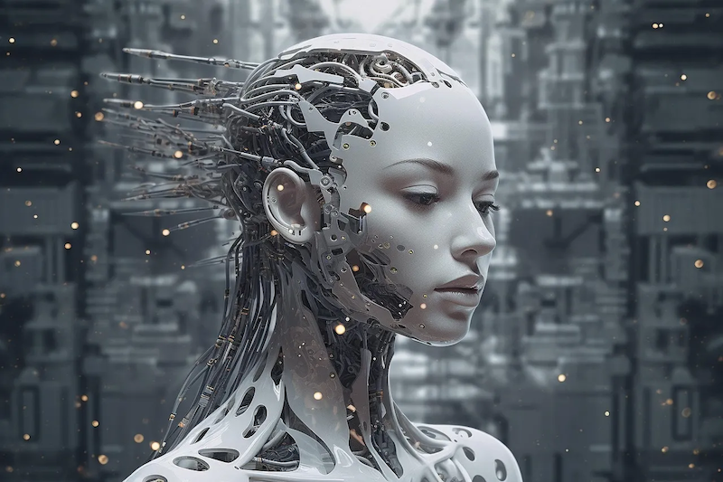

# **Python w raportowaniu zarządczym**

Shareo, Warszawa 16-17 październik 2025

Daniel Wójcik, MBA

## Dlaczego Python sprawdza się w raportowaniu zarządczym

- Jeden spójny stos technologiczny — od ekstrakcji danych, przez transformacje, analitykę, aż po wizualizację i aplikacje webowe — bez potrzeby korzystania z osobnych narzędzi BI.
- Ekosystem otwarto-źródłowy: brak kosztów licencji (lub dużo niższe) i możliwość rozbudowy dostosowanej do potrzeb organizacji.
- Duża społeczność i stale rozwijane biblioteki (pandas, NumPy, scikit-learn, Plotly, itp.).
- Automatyzacja zadań, wersjonowanie kodu, powtarzalność procesów, łatwość integracji, kontenerami, chmurą.
- Możliwość „robienia więcej” niż typowe narzędzia BI — np. symulacje, prognozy, algorytmy uczenia maszynowego, niestandardowe transformacje.

## Architektura typowego rozwiązania raportowego

1. **Źródła danych**: systemy ERP, CRM, CSV/XLS, bazy danych, API zewnętrzne
2. **Ingestion / ETL**: zadania automatyczne z wykorzystaniem Apache Airflow
3. **Warstwa transformacji / model danych**: pandas, NumPy
4. **Analiza / modele predykcyjne**: scikit-learn, statystyka, analityka wspomagająca
5. **Wizualizacja i interfejs**: matplotlib (statyczne), Plotly (interaktywne), aplikacje Dash lub Streamlit
6. **Publikacja / dostęp**: deployment (serwer, chmura, Docker, autoryzacja)
7. **Monitorowanie i utrzymanie**: logi, alerty, testy danych, wersjonowanie kodu

## NumPy — podstawa obliczeń numerycznych

- NumPy (Numerical Python) zapewnia tablice wielowymiarowe (ndarray) i bardzo wydajne, niskopoziomowe operacje wektorowe.
- W praktyce w raportowaniu: przeliczenia stóp wzrostu, indeksy, normalizacje, alokacje proporcjonalne, operacje macierzowe, symulacje Monte Carlo, testy wariancji itp.
- Dzięki operacjom wektorowym (bez pętli Python) działa bardzo wydajnie na dużych zbiorach danych.
- Operacje wewnętrzne wykorzystują zoptymalizowane biblioteki C/Fortran — bardzo szybkie mnożenia macierzy itp.

## Pandas — manipulacja, model danych, pipeline transformacji

- pandas dostarcza struktur: DataFrame i Series, elastyczne mechanizmy filtrowania, grupowania, agregacji, pivotów, operacji okienkowych (rolling, expanding) oraz łączeń (join/merge).
- W kontekście raportowania:
  - model plan-vs-wykonanie, warstwy „gold”, „silver” danych, agregaty według jedności organizacyjnej, czas, produktów itp.
  - transformacje krok po kroku (pipeline), możliwość łatwego dodawania kolejnych etapów, debugowanie transformacji.
  - łączenia z danymi referencyjnymi (np. słowniki, mapowania)
  - przetwarzanie danych czasowych (reindeksacje, forward/backward fill, interpolacje dla braków)
- Dzięki temu kod przetwarzający dane staje się czytelny, wersjonowalny i łatwy do testowania.

## Matplotlib — klasyczne wykresy publikacyjne

- Matplotlib to bazowa biblioteka do wykresów w Pythonie, pozwalająca na bardzo precyzyjny poziom kontroli nad elementami (osie, skale, adnotacje, style, layout).
- Idealna gdy potrzebujesz dobrze skompilowanego wykresu do druku, PDF, raportu statycznego.
- Możliwość eksportu do wielu formatów (PNG, SVG, PDF).
- W raportowaniu zarządczym: statyczne wykresy w dokumentach (PDF, PowerPoint), stałe raporty tygodniowe/miesięczne, wydruki.

## Plotly — wykresy interaktywne w przeglądarce

- Plotly py (biblioteka Python) umożliwia tworzenie interaktywnych wykresów (zoom, hover, wybór zakresu, legendy) w standardowej przeglądarce.
- Można używać go niezależnie (np. embed w Dash/Streamlit) lub samodzielnie jako komponent wizualizacji.
- Obsługuje wiele typów wykresów: linie, słupki, heatmapy, mapy geograficzne, 3D, sankey, treemapy itp.
- W interaktywnych dashboardach raportowych: drill-down (np. region → oddział), dynamiczne filtry, tooltipy z dodatkowymi informacjami.
- Plotly jest stworzony przez firmę Plotly (biblioteka open source + oferta enterprise)

## Scikit-learn — modele predykcyjne i algorytmy wspomagające decyzje

- Scikit-learn (sklearn) to wszechstronna biblioteka uczenia maszynowego w Pythonie, obejmująca regresje, klasyfikacje, klasteryzacje, redukcje wymiaru, transformacje oraz narzędzia do walidacji, cross-validation, pipeline’ów itp.
- W zastosowaniach zarządczych:
  - Prognozy przychodów, kosztów, popytu (np. regresja liniowa, modele ARIMA rozszerzane)
  - Wykrywanie anomalii (odchylenia przychodów, koszty odbiegające od trendu)
  - Segmentacja klientów / produktów (klasteryzacja k-means)
  - Modele rankingowe / klasyfikacyjne (np. ocena ryzyka, scoring)
  - Pipeline integrujący preprocessing + model + walidację (umożliwia wersjonowanie, replikację)
- scikit-learn stanowi standardowe narzędzie ML w projektach analiz i jest dobrze zintegrowany z pandas/NumPy.

## Streamlit — szybkie aplikacje, prototypy, interaktywne raporty

- Streamlit to biblioteka, która pozwala w kilka linijek kodu zamienić skrypt analityczny w interaktywną aplikację webową (bez pisania front-endu).
- Intuicyjna składnia: deklarujesz zmienne (widgety), potem używasz np. st.write(), st.plotly_chart() — aplikacja sama reaguje.
- Wbudowany mechanizm cache’owania, łatwa obsługa uploadów plików, widgetów, formularzy, layoutów (kolumny, sekcje).
- Przykłady w literaturze: budowanie dashboardów populacji (Strumieniowanie danych + interaktywne wykresy) ; automatyzacja raportów biznesowych przy użyciu Streamlit (generowanie widoków interaktywnych) ; łączenie Streamlit + Pandas + Plotly w aplikacjach sprzedażowych
- Ograniczenia: mniej elastyczny w kwestii wielostronicowości, routing, autoryzacji (trzeba dokładać własne komponenty), trudności we wdrażaniu przy dużych złożonościach aplikacji (np. niestandardowy UX)
- Z reguły używany jako narzędzie prototypowe lub wewnętrzne aplikacje analityczne.

## Instalacja Python 3.13.8

[figure not shown]

**https://www.python.org/downloads/**

## Instalacja i uruchomienie Jupyter Lab

[figure not shown]

**pip install jupyterlab**

Terminal: jupyter lab